# Effect size: lmer and glm/glmer

size matters

work in progress / enrico toffalini @ psicostat

February 2nd, 2024

### Initial setup

```r
rm(list=ls())
library(lme4)
library(effects)
library(ggplot2)
library(MASS)
compact = function(x,digits=2){return(format(round(x,digits),nsmall=digits))}
ts=25
```

# SMDs with repeated measures / mixed-models

Let’s consider this simple illustrative case with N = 16 divided into two conditions, with each subject providing k = 10 observed responses, all different. With a mixed-model we could model responses like this: **`fit = lmer(score ~ Condition + (1|id), data = df)`**.

If we should report a standardized effect size (i.e., SMD, Cohen’s d), how do we compute it?

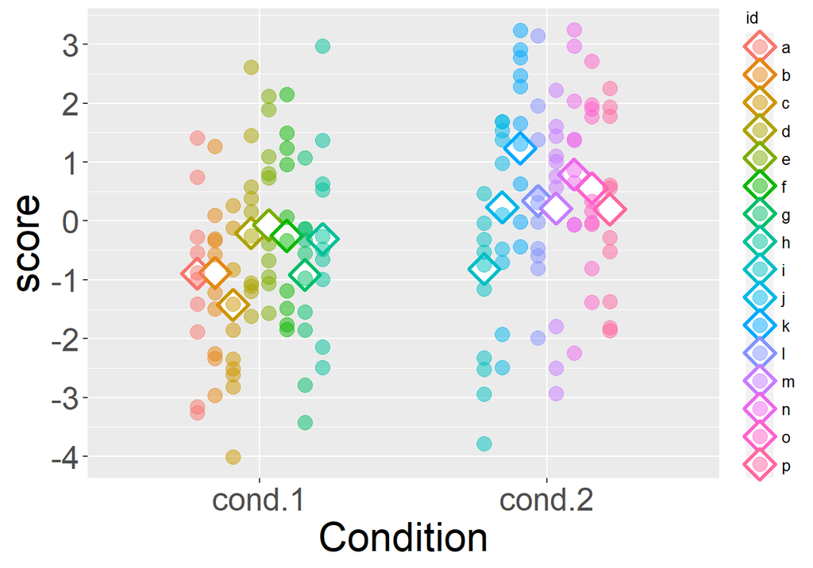

If we consider all observed responses (small circles, which include both within- and between-subject variance) we get: **Cohen’s d = 0.61**

However, if we consider only the (model-estimated, unobserved) true subject scores (diamonds, which include only between-subject variance) we get: **Cohen’s d = 1.80**

How do we estimate the second Cohen’s d using ONLY the model parameters in the summary? Let’s see the summary:

```r
summary(fit)
```

```
## Linear mixed model fit by REML ['lmerMod']
## Formula: score ~ Condition + (1 | id)
##    Data: df
##
## REML criterion at convergence: 592.2
##
## Scaled residuals:
##      Min       1Q   Median       3Q      Max
## -2.15519 -0.65057  0.02104  0.78849  2.24219
##
## Random effects:
##  Groups   Name        Variance Std.Dev.
##  id       (Intercept) 0.4295   0.6554
##  Residual             2.1316   1.4600
## Number of obs: 160, groups:  id, 16
##
## Fixed effects:
##                 Estimate Std. Error t value
## (Intercept)      -0.6188     0.2834  -2.183
## Conditioncond.2   0.9640     0.4008   2.405
##
## Correlation of Fixed Effects:
##             (Intr)
## Condtncnd.2 -0.707
```

We may divide the “raw coefficient” by either the total SD, or only by the estimated between-subject (id) SD:

→ For total variance/SD: **0.96 / sqrt(0.66<sup>2</sup> + 1.46<sup>2</sup>) = 0.60**

→ For estimated between-subject SD only: **0.96 / 0.66 = 1.47**

# GLM: Poisson (with Gamma it’s more or less the same)

Let’s model a discrete count variable such as reading errors. Age is the predictor. Reading errors monotonously decrease throughout primary school. However, decrease is not linear: it smoothly converges towards zero, and M and SD are related.

We had already talked about the problem here: **https://www.memoryandlearninglab.it/wp-content/uploads/2023/10/glm_e_overdispersion3.html**

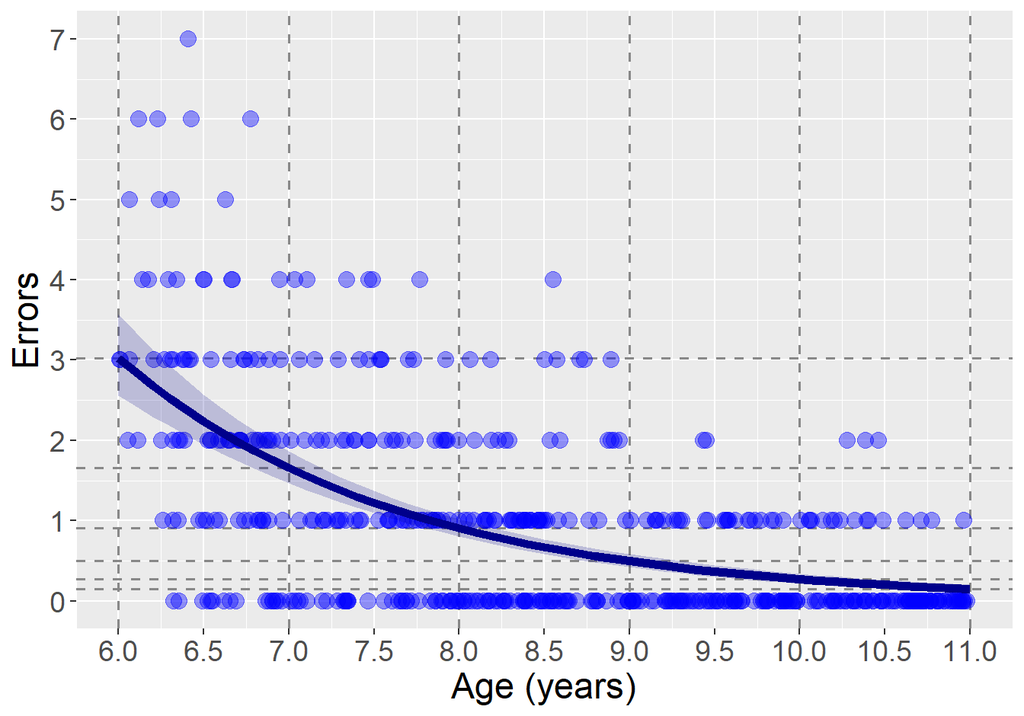

The mean linear decrease is about -**-0.50** errors *per year*, so **every two years we should observe a decrease of about -1.00 reading errors**.

However… from **6** to **7** years we get an expected decrease of **-1.37** reading errors, whereas from **7** to **8** we get an expected decrease of **-0.75** reading errors.

So, what remain constant? What can be reported as a meaningful effect size? It’s the percentage of reduction of reading errors *per time unit*.

**Every +1 year**, the expected number of remaining reading errors is **55%** compared to the expected number of the previous year. **After +2 years, the expected number of remaining reading errors is 30% compared to the previous observation**. These decreases are **constant over time**.

How do we get these estimates? Let’s have a look at the Poisson model summary:

```r
summary(fit)
```

```
## Generalized linear mixed model fit by maximum likelihood (Laplace
##   Approximation) [glmerMod]
##  Family: poisson  ( log )
## Formula: errors ~ age + (1 | id)
##    Data: df
##
##      AIC      BIC   logLik deviance df.resid
##   1160.3   1173.0   -577.2   1154.3      497
##
## Scaled residuals:
##     Min      1Q  Median      3Q     Max
## -1.4797 -0.6413 -0.4043  0.5184  3.7210
##
## Random effects:
##  Groups Name        Variance Std.Dev.
##  id     (Intercept) 0.05813  0.2411
## Number of obs: 500, groups:  id, 500
##
## Fixed effects:
##             Estimate Std. Error z value Pr(>|z|)
## (Intercept)  4.72878    0.31624   14.95   <2e-16 ***
## age         -0.60363    0.04138  -14.59   <2e-16 ***
## ---
## Signif. codes:  0 '***' 0.001 '**' 0.01 '*' 0.05 '.' 0.1 ' ' 1
##
## Correlation of Fixed Effects:
##     (Intr)
## age -0.984
```

The estimate for **`age`** is **-0.60**.

The effect on the linear scale **per +1 year** is **`exp(age)`** that is **0.55**, so the percentage is **55**% (i.e., remaining percentage of reading errors after every year).

**Per +2 years** we calculate **`exp(age*2)`**, that is **0.30**, thus a remaining percentage of **30**%.

# Binomial regression

Let’s model a discrete sum score variable measuring solved math problems out of 15 in a task. Accuracy ranges from 0% (sum score = 0) to 100% (sum score = 15). Age is the predictor. Accuracy monotonously increase throughout primary school. However, increase is not linear: it is constrained between two extreme bounds, and “fastest” in the middle, and once again M and SD are related.

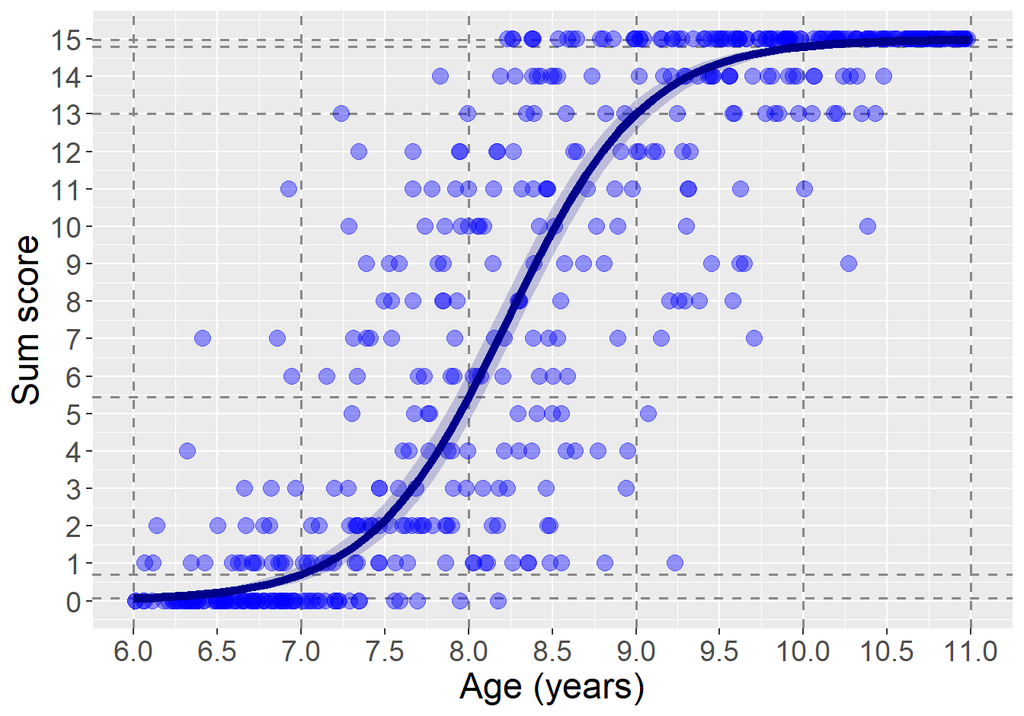

The linear increase *per year* is about +**3.71** correctly solved math problems… this is not bad, but clearly inaccurate when close to the bounds.

A better estimate is the *Odds Ratio*, which here is **11.50**. This is an appropriate effect size index for binomial regressions. But how is it interpreted?

Every +1 year of age, the **odds** of correctly solving a problem is **11.50 times the odds of the year before**.

How do we get this estimate? Let’s have a look at the Binomial model summary:

```r
summary(fit)
```

```
## Generalized linear mixed model fit by maximum likelihood (Laplace
##   Approximation) [glmerMod]
##  Family: binomial  ( logit )
## Formula: cbind(sumscore, 15 - sumscore) ~ age + (1 | id)
##    Data: df
##
##      AIC      BIC   logLik deviance df.resid
##   1712.5   1725.1   -853.2   1706.5      497
##
## Scaled residuals:
##      Min       1Q   Median       3Q      Max
## -1.08730 -0.34507  0.07611  0.30624  1.01348
##
## Random effects:
##  Groups Name        Variance Std.Dev.
##  id     (Intercept) 2.787    1.669
## Number of obs: 500, groups:  id, 500
##
## Fixed effects:
##              Estimate Std. Error z value Pr(>|z|)
## (Intercept) -20.10317    0.81904  -24.55   <2e-16 ***
## age           2.44249    0.09836   24.83   <2e-16 ***
## ---
## Signif. codes:  0 '***' 0.001 '**' 0.01 '*' 0.05 '.' 0.1 ' ' 1
##
## Correlation of Fixed Effects:
##     (Intr)
## age -0.993
```

The estimate for **`age`** is **2.44**.

The *Odds Ratio* is **`exp(age)`** that is **11.50**.

**Note that the *Odds Ratio* depends on the “age” metrics, which is expressed in years: with age in months, we would get a different estimate. Specifically, it would be 11.50`^(1/12)` = 1.23**